# Project TMDB

## PROJECT : Investigate a TMDB movie Database

## Table of Contents:

- Introduction
- Data Wrangling
- Exploratory Data Analysis
- Conclusions

## 1. Introduction:

- The dataset selected is the TMDB dataset that contains data on around 10k movies and ratings.
- The source of this data is www.kaggle.com.
- The dataset contains information of 10865 movies.
- The dataset contains information like details of budget, runtime of movies, revenue, vote_Avg, popularity, release_year etc of the movies.
- The dataset contains information on movies from year 1960 to 2015.

### The analysis and questions posed are :-

A. General Statistics..

B. What are the movies with max and min

1. Popularity
2. Revenue
3. Budget
4. Runtime
5. Profit

C. What is the average runtime of all movies?

D. What are the top 10 movies by vote average (Average rating) and popularity?

E. Finding top 10 count for:

- Which directors directed max no movies
- Which cast appeared most
- Which genre occured most?

F. What are the characteristics of most profitable movies...?

G. In which year, month we had the most movies making max profits?

- Which month released max,min no of movies overall?
- Which month had sum of profit for all movies max,min?
- Which year released max,min no of movies overall?
- Which year had sum of profit for all movies max,min?

H. Relationship between Various parameters..

The investigations conducted here are exploratory and any associations will be tentative at best, as only visualization and basic correlations are attempted in this project. Any relation inferred will be used only as a pointer for conducting further detailed, statistically backed analyses.

```python
# Importing statements for all of the packages that will be needed
import numpy as np
import pandas as pd
import csv # read and write csv files
from datetime import datetime # operations to parse dates
import matplotlib.pyplot as plt
% matplotlib inline
import seaborn as sns
```

*Let's take a look at TMDB movie database csv file...*

```python
#reading tmdb csv file and storing that to a variable
tmdb_file = pd.read_csv('tmdb-movies.csv')

#calling out first 5 rows (excluding headers) of tmdb database
tmdb_file.head()
```

|  | id | imdb_id | popularity | budget | revenue | original_title | cast | homepage | director | tagline | ... | overview | runtime | genres | production_companies | release_date | vote_count | vote_average | release_year | budget_adj | revenue_adj |
| --- | --- | --- | --- | --- | --- | --- | --- | --- | --- | --- | --- | --- | --- | --- | --- | --- | --- | --- | --- | --- | --- |
| 0 | 135397 | tt0369610 | 32.985763 | 150000000 | 1513528810 | Jurassic World | Chris Pratt\|Bryce Dallas Howard\|Irrfan Khan\|Vi... | http://www.jurassicworld.com/ | Colin Trevorrow | The park is open. | ... | Twenty-two years after the events of Jurassic ... | 124 | Action\|Adventure\|Science Fiction\|Thriller | Universal Studios\|Amblin Entertainment\|Legenda... | 6/9/15 | 5562 | 6.5 | 2015 | 1.379999e+08 | 1.392446e+09 |
| 1 | 76341 | tt1392190 | 28.419936 | 150000000 | 378436354 | Mad Max: Fury Road | Tom Hardy\|Charlize Theron\|Hugh Keays-Byrne\|Nic... | http://www.madmaxmovie.com/ | George Miller | What a Lovely Day. | ... | An apocalyptic story set in the furthest reach... | 120 | Action\|Adventure\|Science Fiction\|Thriller | Village Roadshow Pictures\|Kennedy Miller Produ... | 5/13/15 | 6185 | 7.1 | 2015 | 1.379999e+08 | 3.481613e+08 |
| 2 | 262500 | tt2908446 | 13.112507 | 110000000 | 295238201 | Insurgent | Shailene Woodley\|Theo James\|Kate Winslet\|Ansel... | http://www.thedivergentseries.movie/#insurgent | Robert Schwentke | One Choice Can Destroy You | ... | Beatrice Prior must confront her inner demons ... | 119 | Adventure\|Science Fiction\|Thriller | Summit Entertainment\|Mandeville Films\|Red Wago... | 3/18/15 | 2480 | 6.3 | 2015 | 1.012000e+08 | 2.716190e+08 |
| 3 | 140607 | tt2488496 | 11.173104 | 200000000 | 2068178225 | Star Wars: The Force Awakens | Harrison Ford\|Mark Hamill\|Carrie Fisher\|Adam D... | http://www.starwars.com/films/star-wars-episod... | J.J. Abrams | Every generation has a story. | ... | Thirty years after defeating the Galactic Empi... | 136 | Action\|Adventure\|Science Fiction\|Fantasy | Lucasfilm\|Truenorth Productions\|Bad Robot | 12/15/15 | 5292 | 7.5 | 2015 | 1.839999e+08 | 1.902723e+09 |
| 4 | 168259 | tt2820852 | 9.335014 | 190000000 | 1506249360 | Furious 7 | Vin Diesel\|Paul Walker\|Jason Statham\|Michelle ... | http://www.furious7.com/ | James Wan | Vengeance Hits Home | ... | Deckard Shaw seeks revenge against Dominic Tor... | 137 | Action\|Crime\|Thriller | Universal Pictures\|Original Film\|Media Rights ... | 4/1/15 | 2947 | 7.3 | 2015 | 1.747999e+08 | 1.385749e+09 |

5 rows × 21 columns

# 2. Data Wrangling:

#### a) What needs to be cleaned and corrected?

Based on the questions brainstormed above, we want to know do we have all the valid values of the variables that we want to calculate and how can this data be trimmed so we can only have the columns we need. This will also make our dataset clean and easy for us to calculate what we want.

- As you can see in this database of movies there are lots of movies where the `budget or revenue have a value of '0'` which means that the `values of those variables of those movies has not been recorded`. Calculating the profits of these movies would lead to inappropriate results. So we need to delete these rows.
- We will remove all `NULL value` rows in the data set which may affect our analysis.
- Also this dataset has some `duplicate rows`. We have to clean that too for appropriate results.
- We have check if all columns are in the `desired data type`, if not then we have to change it.
- We will also remove unnecessory columns such as `'imdb_id', 'homepage', 'keywords', 'overview', 'production_companies'` This needs to be done because either these columns contain a large no. of null values or doesn't seem to be promising enough to be fit for some analysis.
- The outliers were as such not found. ( Those with value 0 were removed as mentioned in first point).

#### b) Removing Unwanted Columns:

```python
del_col = ['imdb_id', 'budget', 'revenue', 'homepage', 'keywords', 'overview', 'production_companies', 'tagline']
#deleting the columns from the database
tmdb_file = tmdb_file.drop(del_col,1)
tmdb_file.head(3)
```

|  | id | popularity | original_title | cast | director | runtime | genres | release_date | vote_count | vote_average | release_year | budget_adj | revenue_adj |
| --- | --- | --- | --- | --- | --- | --- | --- | --- | --- | --- | --- | --- | --- |
| 0 | 135397 | 32.985763 | Jurassic World | Chris Pratt\|Bryce Dallas Howard\|Irrfan Khan\|Vi... | Colin Trevorrow | 124 | Action\|Adventure\|Science Fiction\|Thriller | 6/9/15 | 5562 | 6.5 | 2015 | 1.379999e+08 | 1.392446e+09 |
| 1 | 76341 | 28.419936 | Mad Max: Fury Road | Tom Hardy\|Charlize Theron\|Hugh Keays-Byrne\|Nic... | George Miller | 120 | Action\|Adventure\|Science Fiction\|Thriller | 5/13/15 | 6185 | 7.1 | 2015 | 1.379999e+08 | 3.481613e+08 |
| 2 | 262500 | 13.112507 | Insurgent | Shailene Woodley\|Theo James\|Kate Winslet\|Ansel... | Robert Schwentke | 119 | Adventure\|Science Fiction\|Thriller | 3/18/15 | 2480 | 6.3 | 2015 | 1.012000e+08 | 2.716190e+08 |

#### c) Changing 0 values to NaN:

Now lets check if we have any movie with a *runtime, budget_adj, revenue_adj* value of 0. If we have any, we will replace with NaN. This is because these values may not have been recorded when data was collected so we will ignore them in analysis.

```python
#replacing 0 with NaN of runtime column of the dataframe
tmdb_file['runtime'] = tmdb_file['runtime'].replace(0, np.NaN)
tmdb_file['budget_adj'] = tmdb_file['budget_adj'].replace(0, np.NaN)
tmdb_file['revenue_adj'] = tmdb_file['revenue_adj'].replace(0, np.NaN)
```

#### d) General Properties of dataset provided:

```python
tmdb_file.info()
tmdb_file.shape
```

```
<class 'pandas.core.frame.DataFrame'>
RangeIndex: 10866 entries, 0 to 10865
Data columns (total 13 columns):
id                10866 non-null int64
popularity        10866 non-null float64
original_title    10866 non-null object
cast              10790 non-null object
director          10822 non-null object
runtime           10835 non-null float64
genres            10843 non-null object
release_date      10866 non-null object
vote_count        10866 non-null int64
vote_average      10866 non-null float64
release_year      10866 non-null int64
budget_adj        5170 non-null float64
revenue_adj       4850 non-null float64
dtypes: float64(5), int64(3), object(5)
memory usage: 1.1+ MB
```

```
(10866, 13)
```

- *NULL values in dataset:*

```python
tmdb_file.isnull().sum()
```

```
id                   0
popularity           0
original_title       0
cast                76
director            44
runtime             31
genres              23
release_date         0
vote_count           0
vote_average         0
release_year         0
budget_adj        5696
revenue_adj       6016
dtype: int64
```

- *Duplicates in dataset:*

```python
tmdb_file.duplicated().sum()
```

```
1
```

- *Unique values in dataset:*

```python
tmdb_file.nunique()
```

```
id                10865
popularity        10814
original_title    10571
cast              10719
director           5067
runtime             246
genres             2039
release_date       5909
vote_count         1289
vote_average         72
release_year         56
budget_adj         2613
revenue_adj        4839
dtype: int64
```

Id is best measure to be set as main differentiating primary key.

#### e) Removing NULL and Duplicate values:

```python
tmdb_file.dropna(subset=['cast','director','genres','budget_adj','revenue_adj'], how='any', inplace = True)
tmdb_file= tmdb_file.drop_duplicates(keep=False)
tmdb_file.isnull().sum()
```

```
id                0
popularity        0
original_title    0
cast              0
director          0
runtime           0
genres            0
release_date      0
vote_count        0
vote_average      0
release_year      0
budget_adj        0
revenue_adj       0
dtype: int64
```

```python
tmdb_file.duplicated().sum()
```

```
0
```

```python
tmdb_file.shape
```

```
(3848, 13)
```

#### f) Lets see if all the columns are in the format that we want for our calculations.

```python
#showing the datatypes of all the columns
tmdb_file.dtypes
```

```
id                  int64
popularity        float64
original_title     object
cast               object
director           object
runtime           float64
genres             object
release_date       object
vote_count          int64
vote_average      float64
release_year        int64
budget_adj        float64
revenue_adj       float64
dtype: object
```

#### 1. We need to convert the 'release_date' column to date format

#### 2. We can also see we have float values for 'budget_adj' and 'revenue_adj' columns, since we dont need float but in int datatype, lets convert them.

- converting date to datetime format

```python
#calling the column which need to be formatted in datetime and storing those values in them
tmdb_file.release_date = pd.to_datetime(tmdb_file['release_date'])

#showing the dataset
tmdb_file.head(2)
```

|  | id | popularity | original_title | cast | director | runtime | genres | release_date | vote_count | vote_average | release_year | budget_adj | revenue_adj |
| --- | --- | --- | --- | --- | --- | --- | --- | --- | --- | --- | --- | --- | --- |
| 0 | 135397 | 32.985763 | Jurassic World | Chris Pratt\|Bryce Dallas Howard\|Irrfan Khan\|Vi... | Colin Trevorrow | 124.0 | Action\|Adventure\|Science Fiction\|Thriller | 2015-06-09 | 5562 | 6.5 | 2015 | 1.379999e+08 | 1.392446e+09 |
| 1 | 76341 | 28.419936 | Mad Max: Fury Road | Tom Hardy\|Charlize Theron\|Hugh Keays-Byrne\|Nic... | George Miller | 120.0 | Action\|Adventure\|Science Fiction\|Thriller | 2015-05-13 | 6185 | 7.1 | 2015 | 1.379999e+08 | 3.481613e+08 |

- Converting budget_adj and revenue_adj from float to int.

```python
#applymap function changes the columns data type to the type 'argument' we pass
change_coltype = ['budget_adj', 'revenue_adj']
tmdb_file[change_coltype] = tmdb_file[change_coltype].applymap(np.int64)
#showing the datatypes of all columns
tmdb_file.dtypes
```

```
id                         int64
popularity               float64
original_title            object
cast                      object
director                  object
runtime                  float64
genres                    object
release_date      datetime64[ns]
vote_count                 int64
vote_average             float64
release_year               int64
budget_adj                 int64
revenue_adj                int64
dtype: object
```

Now all columns are in the desired format.

##### Now we are through with cleaning and thus proceed to Analysis...

# 3. Exploratory Data Analysis:

Firstly `adding a profit column` required for further analysis:

```python
#assigning a new column which will hold the profit values of each movie.

#the insert function's first argument is an index number given to locate the column, second argument takes the name of the new column...
#...and last but not least it takes the calculation values to output for specific column

#To calculate profit of each movie, we need to substract the budget from the revenue of each movie
tmdb_file.insert(2, 'profit', tmdb_file['revenue_adj'] - tmdb_file['budget_adj'])

#showing the dataset
tmdb_file.head(2)
```

|  | id | popularity | profit | original_title | cast | director | runtime | genres | release_date | vote_count | vote_average | release_year | budget_adj | revenue_adj |
| --- | --- | --- | --- | --- | --- | --- | --- | --- | --- | --- | --- | --- | --- | --- |
| 0 | 135397 | 32.985763 | 1254445953 | Jurassic World | Chris Pratt\|Bryce Dallas Howard\|Irrfan Khan\|Vi... | Colin Trevorrow | 124.0 | Action\|Adventure\|Science Fiction\|Thriller | 2015-06-09 | 5562 | 6.5 | 2015 | 137999939 | 1392445892 |
| 1 | 76341 | 28.419936 | 210161353 | Mad Max: Fury Road | Tom Hardy\|Charlize Theron\|Hugh Keays-Byrne\|Nic... | George Miller | 120.0 | Action\|Adventure\|Science Fiction\|Thriller | 2015-05-13 | 6185 | 7.1 | 2015 | 137999939 | 348161292 |

### QA. General statistics:

```python
tmdb_file.describe()
```

|  | id | popularity | profit | runtime | vote_count | vote_average | release_year | budget_adj | revenue_adj |
| --- | --- | --- | --- | --- | --- | --- | --- | --- | --- |
| count | 3848.000000 | 3848.000000 | 3.848000e+03 | 3848.000000 | 3848.000000 | 3848.000000 | 3848.000000 | 3.848000e+03 | 3.848000e+03 |
| mean | 39884.546778 | 1.193088 | 9.296941e+07 | 109.221933 | 528.495842 | 6.168997 | 2001.255977 | 4.429732e+07 | 1.372667e+08 |
| std | 67257.620158 | 1.475783 | 1.941869e+08 | 19.914794 | 880.422193 | 0.794577 | 11.286229 | 4.481883e+07 | 2.162187e+08 |
| min | 5.000000 | 0.001117 | -4.139124e+08 | 15.000000 | 10.000000 | 2.200000 | 1960.000000 | 0.000000e+00 | 2.000000e+00 |
| 25% | 6071.000000 | 0.463291 | -1.498934e+06 | 95.750000 | 71.000000 | 5.700000 | 1995.000000 | 1.315864e+07 | 1.843827e+07 |
| 50% | 11311.000000 | 0.799015 | 2.746787e+07 | 106.000000 | 205.000000 | 6.200000 | 2004.000000 | 3.007926e+07 | 6.182197e+07 |
| 75% | 38569.750000 | 1.374400 | 1.075787e+08 | 119.000000 | 581.250000 | 6.700000 | 2010.000000 | 6.076720e+07 | 1.635528e+08 |
| max | 417859.000000 | 32.985763 | 2.750137e+09 | 338.000000 | 9767.000000 | 8.400000 | 2015.000000 | 4.250000e+08 | 2.827124e+09 |

From above dataframe we see :

- **Popularity :** We see although `min popularity is 0.001117` and `max is 32.985` but `mean is only 1.19` i.e. only few movies were really popular.
- **Profit_adj :** We find some movies suffered `loss as high as 4 hundred million dollars` while some have managed to make `profit as high as 2.7 billion dollars`..!
- **Runtime :** Average runtime of movies is approximately `109 minutes`.
- **Vote_average :** Voting average ranged between `2.2 to 8.4`. While mean voting average was `6.16` .

### Q B. What are the movies with max and min

1. Popularity
2. Revenue
3. Budget
4. Runtime
5. Profit

```python
#Function which calculates max and min values of columns
#taking column name as arguments

def highest_lowest(col_name):

    #Highest
    #taking the index value of the highest number in profit column
    highest = tmdb_file[col_name].idxmax()
    #calling by index number,storing that row info to a variable
    highest_details = pd.DataFrame(tmdb_file.loc[highest])

    #lowest
    #same processing as above
    lowest = tmdb_file[col_name].idxmin()
    lowest_details = pd.DataFrame(tmdb_file.loc[lowest])

    #joining two dataframes
    two_in_one_data = pd.concat([highest_details, lowest_details], axis = 1)

    return two_in_one_data
```

##### 1. Popularity (Max and min):

```python
#calling the function and passing the argument popularity
highest_lowest('popularity')
```

|  | 0 | 7268 |
| --- | --- | --- |
| id | 135397 | 1392 |
| popularity | 32.9858 | 0.001117 |
| profit | 1254445953 | 3653891 |
| original_title | Jurassic World | Born into Brothels |
| cast | Chris Pratt\|Bryce Dallas Howard\|Irrfan Khan\|Vi... | Zana Briski\|Avijit\|Geeta Masi\|Kochi\|Mamuni |
| director | Colin Trevorrow | Zana Briski\|Ross Kauffman |
| runtime | 124 | 85 |
| genres | Action\|Adventure\|Science Fiction\|Thriller | Documentary |
| release_date | 2015-06-09 00:00:00 | 2004-12-08 00:00:00 |
| vote_count | 5562 | 23 |
| vote_average | 6.5 | 6.4 |
| release_year | 2015 | 2004 |
| budget_adj | 137999939 | 404055 |
| revenue_adj | 1392445892 | 4057946 |

`*Jurassic World*` is the movie with max popularity of almost 33.

`*Born in Brothels*` is movie with least popularity of 0.0011.

###### 2.Budget (Max and min):

```python
highest_lowest('budget_adj')
```

|  | 2244 | 3581 |
| --- | --- | --- |
| id | 46528 | 59296 |
| popularity | 0.25054 | 0.52043 |
| profit | -413912431 | 1335 |
| original_title | The Warrior's Way | Love, Wedding, Marriage |
| cast | Kate Bosworth\|Jang Dong-gun\|Geoffrey Rush\|Dann... | Mandy Moore\|Kellan Lutz\|Jessica Szohr\|Autumn F... |
| director | Sngmoo Lee | Dermot Mulroney |
| runtime | 100 | 90 |
| genres | Adventure\|Fantasy\|Action\|Western\|Thriller | Comedy\|Romance |
| release_date | 2010-12-02 00:00:00 | 2011-06-03 00:00:00 |
| vote_count | 74 | 55 |
| vote_average | 6.4 | 5.3 |
| release_year | 2010 | 2011 |
| budget_adj | 425000000 | 0 |
| revenue_adj | 11087569 | 1335 |

We can see that `*The Warriors Way*` had the `highest budget` of all movies in the dataset of about `$425M`. This movie also has a `great loss`. So it makes sense that having the highest budget in all makes the film more harder to have higher revenues and earn more profits.

The least budget of all, `*Love, Wedding, Marriage*` movie of almost `0 budget`. Also making `revenue of 1335` and earning a `profit of $1335`, this may be a local movie release. Because it's kind of impossible to have such low budget and earning low revenues if it has released internationally.

###### 3.Revenue (Max and min):

```python
highest_lowest('revenue_adj')
```

|  | 1386 | 5067 |
| --- | --- | --- |
| id | 19995 | 13537 |
| popularity | 9.43277 | 0.462609 |
| profit | 2586236848 | -7112113 |
| original_title | Avatar | Shattered Glass |
| cast | Sam Worthington\|Zoe Saldana\|Sigourney Weaver\|S... | Hayden Christensen\|Peter Sarsgaard\|ChloÃ« Sevi... |
| director | James Cameron | Billy Ray |
| runtime | 162 | 94 |
| genres | Action\|Adventure\|Fantasy\|Science Fiction | Drama\|History |
| release_date | 2009-12-10 00:00:00 | 2003-11-14 00:00:00 |
| vote_count | 8458 | 46 |
| vote_average | 7.1 | 6.4 |
| release_year | 2009 | 2003 |
| budget_adj | 240886902 | 7112115 |
| revenue_adj | 2827123750 | 2 |

`Avatar movie` has made `most revenue`.. Making a revenue of more than `$2.8B`, it makes a logical sense that the `more revenue you earn the more profit` you gain and as we saw in earlier result, The Warriors Way having most budget had less chance of making profits. It really looks that there's correlation between profit and budget/revenue but we can't say just by looking at few results.

Having `lowest revenue of` `$2, Shattered Glass` movie seems like couldn't sell much tickets.

###### 4. Runtime (Max and min):

```python
highest_lowest('runtime')
```

|  | 2107 | 5162 |
| --- | --- | --- |
| id | 43434 | 24914 |
| popularity | 0.534192 | 0.208637 |
| profit | -17128721 | -6 |
| original_title | Carlos | Kid's Story |
| cast | Edgar RamÃrez\|Alexander Scheer\|Fadi Abi Samra... | Clayton Watson\|Keanu Reeves\|Carrie-Anne Moss\|K... |
| director | Olivier Assayas | Shinichiro Watanabe |
| runtime | 338 | 15 |
| genres | Crime\|Drama\|Thriller\|History | Science Fiction\|Animation |
| release_date | 2010-05-19 00:00:00 | 2003-06-02 00:00:00 |
| vote_count | 35 | 16 |
| vote_average | 6.2 | 6.8 |
| release_year | 2010 | 2003 |
| budget_adj | 18000000 | 11 |
| revenue_adj | 871279 | 5 |

We see the first column shows the data about movie with highest runtime and second column shows the one with lowest runtime with column names as the index number.

Runtime of `15 min`, . Directed by `Shinichiro Watanabe`, the movie `Kid's Story` has the least runtime.

As you see both movies have one thing in common, negative profits!

###### 5. Profit (Max and min):

```python
highest_lowest('profit')
```

|  | 1329 | 2244 |
| --- | --- | --- |
| id | 11 | 46528 |
| popularity | 12.0379 | 0.25054 |
| profit | 2750136651 | -413912431 |
| original_title | Star Wars | The Warrior's Way |
| cast | Mark Hamill\|Harrison Ford\|Carrie Fisher\|Peter ... | Kate Bosworth\|Jang Dong-gun\|Geoffrey Rush\|Dann... |
| director | George Lucas | Sngmoo Lee |
| runtime | 121 | 100 |
| genres | Adventure\|Action\|Science Fiction | Adventure\|Fantasy\|Action\|Western\|Thriller |
| release_date | 1977-03-20 00:00:00 | 2010-12-02 00:00:00 |
| vote_count | 4428 | 74 |
| vote_average | 7.9 | 6.4 |
| release_year | 1977 | 2010 |
| budget_adj | 39575591 | 425000000 |
| revenue_adj | 2789712242 | 11087569 |

As we can see the Directed by George Lucas, `Star Wars film has the highest profit in all, making over $2.7B` in profit in this dataset. May be the highest till now of entire human race but we can't say for sure as this dataset doesn't have all the films released till date.

And the most in loss movie in this dataset is `The Warriors Way`. Going in loss by more than `$400M was directed by Singmoo Lee.`

### Q C. What is the average runtime of all movies and further analysis:

```python
tmdb_file['runtime'].mean()
```

```
109.22193347193347
```

The average runtime of all movies in this dataset is 109 mins approx. We want to get a deeper look and understanding of runtime of all movies so Let's plot it.

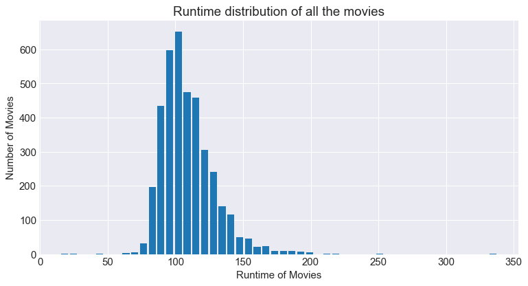

```python
#plotting a histogram of runtime of movies

#gives styles to bg plot
sns.set_style('darkgrid')

#chaging the label size, this will change the size of all plots that we plot from now!
plt.rc('xtick', labelsize = 12)
plt.rc('ytick', labelsize = 12)

#giving the figure size(width, height)
plt.figure(figsize=(10,5), dpi = 90)

#x-axis label name
plt.xlabel('Runtime of Movies', fontsize = 12)

#y-axis label name
plt.ylabel('Number of Movies', fontsize=12)

#title of the graph
plt.title('Runtime distribution of all the movies', fontsize=15)

#giving a histogram plot
plt.hist(tmdb_file['runtime'], rwidth = 0.8, bins =50)
#displays the plot
plt.show()
```

The above graph shows us that how many movies lie between the time interval x1 to x2. We can see the tallest bar here is time interval between `85-100 min(approx)` and around `1200 movies out of 3848` movies have the runtime between these time intervals. So we can also say from this graph that `Mode time of movies is around 85-110 min`, as highest concentration of data points is around this time interval.

```python
#getting specific runtime points at x positions
tmdb_file['runtime'].describe()
```

```
count    3848.000000
mean      109.221933
std        19.914794
min        15.000000
25%        95.750000
50%       106.000000
75%       119.000000
max       338.000000
Name: runtime, dtype: float64
```

So by looking at both, visualiztions and calculations, we can say that..

There are 25% of movies having a runtime of less than `95 min` There are 50% of movies having a runtime of less than `106 min`. This is also the median of runtimes. There are 75% of movies having a runtime of less than `119 min`

### QD. What are the top movies by vote average (Average rating) and popularity?

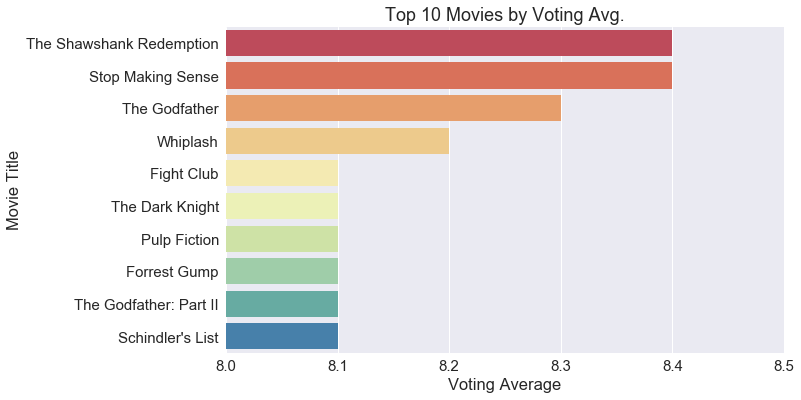

```python
#Get a list of the top 10 movies by voting average
top10 = tmdb_file.nlargest(10,'vote_average')

#Plot the top 10 movies by voting average
sns.set(style="darkgrid");
sns.set(font_scale=1.5);
f, ax = plt.subplots(figsize=(10, 6));
ax = sns.barplot(x='vote_average', y='original_title', data=top10, palette="Spectral");

ax.set(xlim=(8.0,8.5), ylabel="Movie Title", xlabel="Voting Average");
plt.title('Top 10 Movies by Voting Avg.');
```

As shown in the plot above, the top rated movies are `The Shawshank Redemption` and `Stop Making Sense` with a rating of `8.4`

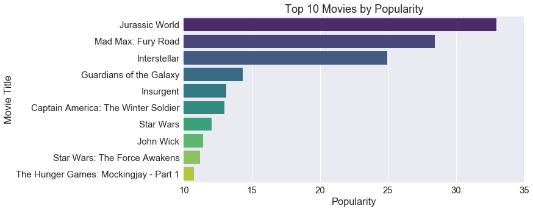

```python
#Get a list of the top 10 movies by voting average
top10 = tmdb_file.nlargest(10,'popularity')

#Plot the top 10 movies by voting average
sns.set(style="darkgrid");
sns.set(font_scale=1.5);
f, ax = plt.subplots(figsize=(10, 5));
ax = sns.barplot(x='popularity', y='original_title', data=top10, palette="viridis");

ax.set(xlim=(10,35), ylabel="Movie Title", xlabel="Popularity");
plt.title('Top 10 Movies by Popularity');
```

We see the most popular movie is `Jurrasic world` with `popularity of about 33`.

### QE Calculating top 10 by count.....

#### (a) Which directors made maximum no of movies?

```python
# Top 10 Directors by movie count:

# This variable will store the count of movies directed by all directors
# Making pandas series and storing the unique values along with count and arranging them in descending order.

director_count = pd.Series(tmdb_file['director']).value_counts(ascending=False)

#showing top 10 values
print("Top 10 directors with max no of movies all over along with count of movies directed by them are")
director_count.head(10)
```

```
Top 10 directors with max no of movies all over along with count of movies directed by them are
```

```
Steven Spielberg     27
Clint Eastwood       24
Ridley Scott         21
Woody Allen          18
Steven Soderbergh    17
Martin Scorsese      17
Tim Burton           16
Robert Zemeckis      15
Oliver Stone         15
Brian De Palma       15
Name: director, dtype: int64
```

[figure not shown]

```python
director_graph= director_count.head(10)
sns.set_style("darkgrid")
sns.set(font_scale=1.5);
f, axis = plt.subplots(figsize=(10, 5));

axis = sns.barplot(x=director_graph.index, y=director_graph.values, palette="Set2");

axis.set( ylabel="Count", xlabel="Cast");
plt.title('Movies Counts by Directors');
plt.xticks(rotation=90);
```

#### (b) Which cast members appeared in most movies?

```python
# Top 10 cast members which appeared most.

# Will make one combined string of all cast members of all movies, separated by '|'
combined_string = tmdb_file['cast'].str.cat(sep = '|')

# Making a pandas series and storing the values separately
combined_string = pd.Series(combined_string.split('|'))

#this will us distinct value count in descending order
cast_count = combined_string.value_counts(ascending = False)
#This will call the extract_data function to count values

#showing top 10 values
print("Top 10 cast members appearing max number of times in movies and their counts")
cast_count.head(10)
```

```
Top 10 cast members appearing max number of times in movies and their counts
```

```
Robert De Niro        52
Bruce Willis          46
Samuel L. Jackson     44
Nicolas Cage          43
Matt Damon            36
Johnny Depp           35
Sylvester Stallone    34
Harrison Ford         34
Morgan Freeman        34
Tom Hanks             34
dtype: int64
```

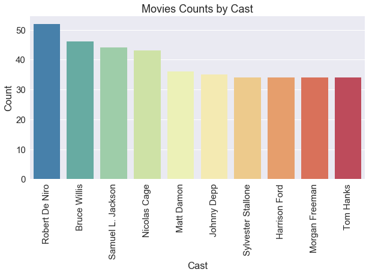

```python
cast_graph= cast_count.head(10)
sns.set_style("darkgrid")
sns.set(font_scale=1.5);
f, axis = plt.subplots(figsize=(10, 5));

axis = sns.barplot(x=cast_graph.index, y=cast_graph.values, palette="Spectral_r");

axis.set( ylabel="Count", xlabel="Cast");
plt.title('Movies Counts by Cast');
plt.xticks(rotation=90);
```

#### (c) Which genre appeared most?

```python
# Top 10 genres which appeared most.

# Will make one combined string of all genres of all movies, separated by '|'
combined_string = tmdb_file['genres'].str.cat(sep = '|')

# Making a pandas series and storing the values separately
combined_string = pd.Series(combined_string.split('|'))

#this will give us distinct value count in descending order
genre_count = combined_string.value_counts(ascending = False)
#This will call the extract_data function to count values

#showing top 10 values
print("Top 10 genres which appeared most in movies and their counts")
genre_count.head(10)
```

```
Top 10 genres which appeared most in movies and their counts
```

```
Drama              1752
Comedy             1357
Thriller           1202
Action             1084
Adventure           749
Romance             666
Crime               650
Science Fiction     518
Horror              463
Family              425
dtype: int64
```

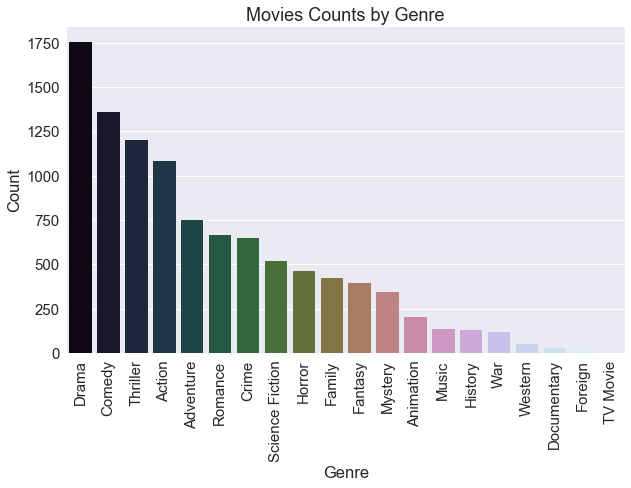

```python
genre_graph= genre_count
sns.set_style("darkgrid")
sns.set(font_scale=1.5);
f, axis = plt.subplots(figsize=(10, 6));

axis = sns.barplot(x=genre_graph.index, y=genre_graph.values, palette="cubehelix");

axis.set( ylabel="Count", xlabel="Genre");
plt.title('Movies Counts by Genre');
plt.xticks(rotation=90);
```

### QF. What attributes do the most profitable movies have?

```python
tmdb_profit = tmdb_file[tmdb_file['profit'] >= 10000000]  #making a dataframe with only those values where profit >= 100000000

#creating a new dataframe profit_adj with only those movies that have profit greater than 50000000.

#reindexing new dataframe
tmdb_profit.index = range(len(tmdb_profit))

#will initialize dataframe from 1 instead of 0
tmdb_profit.index = tmdb_profit.index + 1
```

##### Finding characteristics of most profitable movies:

```python
len(tmdb_profit)              #no of movies with max profit...
```

```
2362
```

```python
def avg_fuc(column_name):     #common function to compute mean of various parameters of most profitable movies..
    return tmdb_profit[column_name].mean()
```

```python
avg_fuc('budget_adj')         # average 'budget' of most profitable movies...
```

```
52670398.94538527
```

```python
avg_fuc('revenue_adj')        # average 'revenue' of most profitable movies..
```

```
211201955.60203218
```

```python
avg_fuc('profit')             #average 'profit' of most profitable movies...
```

```
158531556.6566469
```

```python
def extract_data(column_name):      # function to seperate various strings in a column cell seperated by '|'
    #will take a column, and separate the string by '|'
    all_data = tmdb_profit[column_name].str.cat(sep = '|')

    #giving pandas series and storing the values separately
    all_data = pd.Series(all_data.split('|'))

    #this will us value in descending order
    count = all_data.value_counts(ascending = False)

    return count
```

```python
director_count = extract_data('director')
#showing top 5 directors with most profitable movies
director_count.head()
```

```
Steven Spielberg    27
Clint Eastwood      20
Tim Burton          16
Ridley Scott        15
Robert Zemeckis     14
dtype: int64
```

```python
cast_count = extract_data('cast')
#showing top 5 cast members with most profitable movies
cast_count.head()
```

```
Robert De Niro    33
Bruce Willis      32
Tom Hanks         31
Tom Cruise        31
Brad Pitt         29
dtype: int64
```

```python
genre_count = extract_data('genres')
#showing top 5 genres of most profitable movies
genre_count.head()
```

```
Drama        955
Comedy       861
Thriller     714
Action       706
Adventure    537
dtype: int64
```

```python
Budget_max = tmdb_profit['budget_adj'].max()
Budget_min = tmdb_profit['budget_adj'].min()
print(Budget_max,Budget_min)
```

```
368371256 224
```

### QG. In which year, month we had the most movies making max profits?

- Which month released max,min no of movies overall?
- Which month had sum of profit for all movies max,min?
- Which year released max,min no of movies overall?
- Which year had sum of profit for all movies max,min?

###### Which month released max,min no of movies overall?

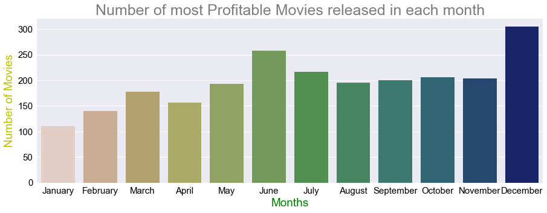

```python
#for answering this question we need to group all of the months of years and then calculate the profits of those months
#giving a new dataframe which gives 'release-date' as index
index_release_date = tmdb_profit.set_index('release_date')

#now we need to group all the data by month, since release date is in form of index, we extract month from it
groupby_index = index_release_date.groupby(index_release_date.index.month)

#this will give us how many movies are released in each month
monthly_movie_count = pd.DataFrame(groupby_index['profit'].count())

#giving a list of months
month_list = ['January', 'February', 'March', 'April', 'May', 'June', 'July', 'August', 'September', 'October', 'November', 'December']

monthly_movie_count_bar = sns.barplot(x = monthly_movie_count.index, y = monthly_movie_count['profit'],palette='gist_earth_r')

#setting size of the graph
monthly_movie_count_bar.figure.set_size_inches(15,5)

#setting the title and customizing
monthly_movie_count_bar.axes.set_title('Number of most Profitable Movies released in each month', fontsize = 25, alpha = 0.6)

#setting x-label
monthly_movie_count_bar.set_xlabel("Months", color="g", fontsize = 19)
#setting y-label
monthly_movie_count_bar.set_ylabel("Number of Movies", color="y", fontsize = 19)

#customizing axes values
monthly_movie_count_bar.tick_params(labelsize = 15, labelcolor="black")

#rotating the x-axis values to make it readable
monthly_movie_count_bar.set_xticklabels(month_list, rotation = 0, size = 15)

#shows the plot
plt.show()
```

The months with `max no of profitable movie releases` are `December, June, July, October`..

`Jan` was the month with `min no. of profitable movie releases`..

##### Which months had sum of profit for all movies max,min?

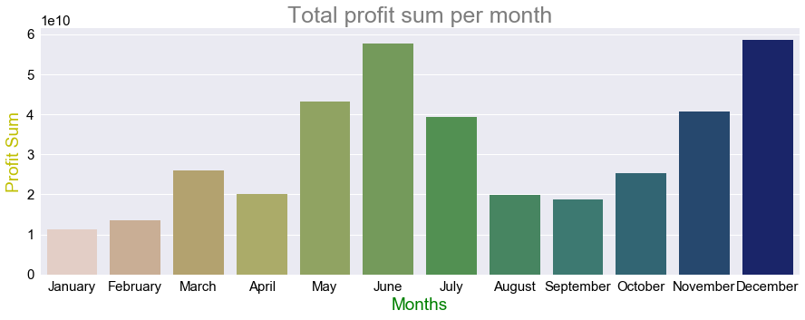

```python
#for answering this question we need to group all of the months of years and then calculate the sum of profits of those months

#now we need to group all the data by month, since release date is in form of index, we extract month from it
groupby_index = index_release_date.groupby(index_release_date.index.month)

#this will give us how many movies are released in each month
monthly_profit_sum = pd.DataFrame(groupby_index['profit'].sum())

#giving a list of months
month_list = ['January', 'February', 'March', 'April', 'May', 'June', 'July', 'August', 'September', 'October', 'November', 'December']

monthly_profit_sum_bar = sns.barplot(x = monthly_profit_sum.index, y = monthly_profit_sum['profit'],palette='gist_earth_r')

#setting size of the graph
monthly_profit_sum_bar.figure.set_size_inches(15,5)

#setting the title and customizing
monthly_profit_sum_bar.axes.set_title('Total profit sum per month', fontsize = 25, alpha = 0.6)

#setting x-label
monthly_profit_sum_bar.set_xlabel("Months", color="g", fontsize = 19)
#setting y-label
monthly_profit_sum_bar.set_ylabel("Profit Sum", color="y", fontsize = 19)

#customizing axes values
monthly_profit_sum_bar.tick_params(labelsize = 15, labelcolor="black")

#rotating the x-axis values to make it readable
monthly_profit_sum_bar.set_xticklabels(month_list, rotation = 0, size = 15)

#shows the plot
plt.show()
```

The months with least profits were: `January, Febreuary, September`

###### Which year released max,min no of profitable movies overall?

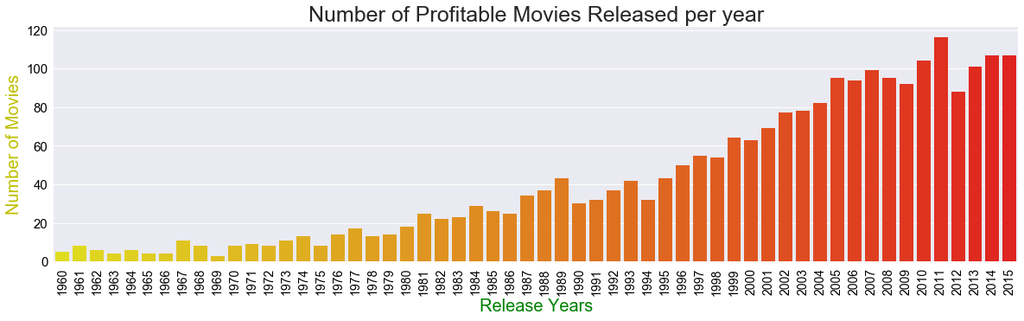

```python
#for answering this question we need to group all of the months of years and then calculate the profits of those months
#giving a new dataframe which gives 'release_year' as index
index_release_year = tmdb_profit.set_index('release_year')

#now we need to group all the data by release_year
groupby_index = index_release_year.groupby('release_year')

#this will give us how many movies are released in each year
yearly_movie_count = pd.DataFrame(groupby_index['profit'].count())

#giving a list of years
year_list = yearly_movie_count.index

yearly_movie_count_bar = sns.barplot(x = yearly_movie_count.index, y = yearly_movie_count['profit'],palette='autumn_r')

#setting size of the graph
yearly_movie_count_bar.figure.set_size_inches(20,5)

#setting the title and customizing
yearly_movie_count_bar.axes.set_title('Number of Profitable Movies Released per year', fontsize = 25)

#setting x-label
yearly_movie_count_bar.set_xlabel("Release Years", color="g", fontsize = 20)
#setting y-label
yearly_movie_count_bar.set_ylabel("Number of Movies", color="y", fontsize = 20)

#customizing axes values
yearly_movie_count_bar.tick_params(labelsize = 15, labelcolor="black")

#rotating the x-axis values to make it readable
yearly_movie_count_bar.set_xticklabels(year_list, rotation = 90, size = 14)

#shows the plot
plt.show()
```

We see as years passed by the no of profitable movies released per year too increased..

Years with max profitable movie releases: `2011, 2014, 2015, 2010`

Years with min profitable movie releases: `1969, 1966, 1963, 1965`

##### Which year had sum of profit for all movies max,min?

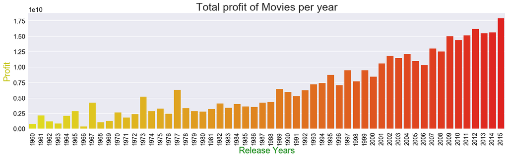

```python
#for answering this question we need to group all of the months of years and then calculate the profits of those months

#now we need to group all the data by release_year
groupby_index = index_release_year.groupby('release_year')

#this will give us how many movies are released in each year
yearly_profit_sum = pd.DataFrame(groupby_index['profit'].sum())

#giving a list of years
year_list = yearly_profit_sum.index

yearly_profit_sum_bar = sns.barplot(x = yearly_profit_sum.index, y = yearly_profit_sum['profit'], palette='autumn_r')

#setting size of the graph
yearly_profit_sum_bar.figure.set_size_inches(20,5)

#setting the title and customizing
yearly_profit_sum_bar.axes.set_title('Total profit of Movies per year', fontsize = 25)

#setting x-label
yearly_profit_sum_bar.set_xlabel("Release Years", color="g", fontsize = 20)
#setting y-label
yearly_profit_sum_bar.set_ylabel("Profit", color="y", fontsize = 20)

#customizing axes values
yearly_profit_sum_bar.tick_params(labelsize = 15, labelcolor="black")

#rotating the x-axis values to make it readable
yearly_profit_sum_bar.set_xticklabels(year_list, rotation = 90, size = 14)

#shows the plot
plt.show()
```

Total profit earned by most profitable movies per year also seem to increase with passe=ing years..

Most profitable years: `2015, 2012, 2014, 2013`

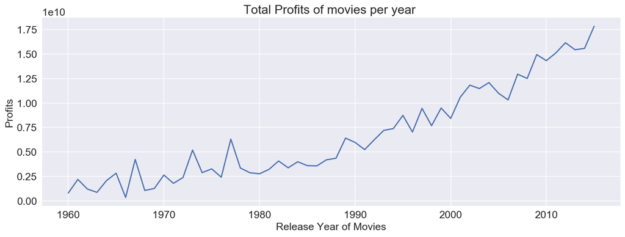

```python
#Line plot used for this
#Since we want to know the profits of movies for every year we need to group all the movies for those years

#the groupby function below collects all the movies for that year and then the profits of all those movies for that years is been added
#and storing all this in variable
profits_each_year = tmdb_profit.groupby('release_year')['profit'].sum()

#giving the figure size(width, height)
plt.figure(figsize=(15,5), dpi = 130)

#labeling x-axis
plt.xlabel('Release Year of Movies', fontsize = 15)
#labeling y-axis
plt.ylabel('Profits', fontsize = 15)
#title of a the plot
plt.title('Total Profits of movies per year ')

#plotting what needs to be plotted
plt.plot(profits_each_year)

#showing the plot
plt.show()
```

The general trend depicted by this line graph is of `Increasing trend` with years passing by i.e. as years passed by overall profits made by movies per year too increased..

```python
#printing out Total profit of max profitable movies for last 5 years
profits_each_year.tail()
```

```
release_year
2011    15120418593
2012    16165249930
2013    15446457972
2014    15584473366
2015    17838501821
Name: profit, dtype: int64
```

### QH. The Relationship between various parameters:

##### We will view the correlation of variables from our dataset grouped over the years.

```python
#using correlation to determine factors influencing revenues
tmdb_file.corr(method='pearson')
```

|  | id | popularity | profit | runtime | vote_count | vote_average | release_year | budget_adj | revenue_adj |
| --- | --- | --- | --- | --- | --- | --- | --- | --- | --- |
| id | 1.000000 | 0.189046 | -0.069728 | -0.035187 | 0.111559 | -0.000708 | 0.489974 | -0.124086 | -0.088344 |
| popularity | 0.189046 | 1.000000 | 0.516665 | 0.215444 | 0.779975 | 0.317692 | 0.173698 | 0.398828 | 0.546690 |
| profit | -0.069728 | 0.516665 | 1.000000 | 0.235513 | 0.613912 | 0.288577 | -0.132090 | 0.404059 | 0.981859 |
| runtime | -0.035187 | 0.215444 | 0.235513 | 1.000000 | 0.274143 | 0.352418 | -0.112800 | 0.334626 | 0.280878 |
| vote_count | 0.111559 | 0.779975 | 0.613912 | 0.274143 | 1.000000 | 0.387201 | 0.207580 | 0.497638 | 0.654509 |
| vote_average | -0.000708 | 0.317692 | 0.288577 | 0.352418 | 0.387201 | 1.000000 | -0.133066 | 0.036093 | 0.266654 |
| release_year | 0.489974 | 0.173698 | -0.132090 | -0.112800 | 0.207580 | -0.133066 | 1.000000 | 0.075490 | -0.102983 |
| budget_adj | -0.124086 | 0.398828 | 0.404059 | 0.334626 | 0.497638 | 0.036093 | 0.075490 | 1.000000 | 0.570172 |
| revenue_adj | -0.088344 | 0.546690 | 0.981859 | 0.280878 | 0.654509 | 0.266654 | -0.102983 | 0.570172 | 1.000000 |

# 4. Conclusions:

1. Out of given dataset only `3848` movies contained valid data.
2. `*Jurassic World*` is the movie with max popularity of almost 33.
3. `Avatar movie` has made most revenue.. Making a revenue of more than $2.8B
4. `Star Wars` film has the highest profit in all, making over $2.7B
5. `Average runtime` of all movies is approx 109 min.
6. The top rated movies are `The Shawshank Redemption` and `Stop Making Sense` with a rating of 8.4.
7. The directors with max number of movie releases( more than 20) are:
   - `Steven Spielberg` with 27 movies
   - Clint Eastwood with 24 movies
   - Ridley Scott with 21 movies
8. The cast members which appeared in most movies are:
   - `Robert De Niro` with 52 movies
   - Bruce Willis with 46 movies
   - Samuel L. Jackson with 44 movies
   - Nicolas Cage with 43 movies
9. Most filmed genre movies:
   - `Drama` 1752
   - Comedy 1357
   - Thriller 1202
   - Action 1084
10. The characteristics of most profitable movies($10 Million):
    - **Directors** *- Steven Spielberg, Clint Eastwood, Tim Burton, Ridley Scott, Robert Zemeckis*
    - **Cast** *- Tom Cruise, Tom Hanks, Brad Pitt, Robert De Niro, Bruce Willis*
    - **Genre** - Drama, Comedy, Thriller, Action, Adventure
    - **Release months** - May, June, July, November, December.
    - Budget Range: `$224 to $368371256`

#### Limitations of the dataset and analysis:

1. Unnecessory columns needed to be removed such as imdb_id, budget, revenue, homepage, keywords, overview, production_companies, tagline. This was done because either these contained large no. of null values or didn't seem promising enough to be fit for some analysis.
2. We have not considered type of vote - positive or negative or any other value.
3. Also this dataset had one duplicate row. We had to remove that duplicate row for setting one column(here id) as the index of whole dataset.
4. Due to wrangling lot of movie data needed to be removed, so our analysis is limited to partial no. of movies. ( Only those movies were considered, whose data was valid and without any null values...)
5. There were lot of movies where the budget_adj or revenue_adj have a value of '0' which means that the values of those variables had not been recorded. Calculating the profits of these movies would lead to inappropriate results. So we needed to delete those rows.
6. Dropping missing or Null values from variables of our interest might skew our analysis and could show unintentional bias towards relationship being analyzed.
7. There is no normalization or exchanges rate or currency conversion is considered during this analysis and our analysis is limited to the numerical values of revenue, budget etc.